# (11) Linear models in R

Lasse Ruokolainen, Bilot Consulting Oy

Above all, **R** is a statistical tool. In traditional statistics, linear models are the typical choice of methods for analysis. While there are numerous packages in **R** that provide more sophisticated regression implementations, the functions available in base-**R** `stats` package are often sufficient.

# 1 OLS models

In standard regression/analysis of variance a rather strong assumption is that the *residuals* need to be normally distributed. If this is the case, one can use the `lm()` function for analysis, which is used to fit linear models. It can be used to carry out regression, single stratum analysis of variance and analysis of covariance (although `aov()` may provide a more convenient interface for these).

## 1.1 *Model fitting*

```r
# Get data:
data(swiss)

# Fit linear model:
model = lm(Fertility ~ Catholic + Education, data = swiss)

# Get model summary:
summary(model)
```

```
Call:
lm(formula = Fertility ~ Catholic + Education, data = swiss)

Residuals:
    Min      1Q  Median      3Q     Max
-15.042  -6.578  -1.431   6.122  14.322

Coefficients:
            Estimate Std. Error t value Pr(>|t|)
(Intercept) 74.23369    2.35197  31.562  < 2e-16
Catholic     0.11092    0.02981   3.721  0.00056
Education   -0.78833    0.12929  -6.097 2.43e-07

(Intercept) ***
Catholic    ***
Education   ***
---
Signif. codes:
0 ‘***’ 0.001 ‘**’ 0.01 ‘*’ 0.05 ‘.’ 0.1 ‘ ’ 1

Residual standard error: 8.331 on 44 degrees of freedom
Multiple R-squared:  0.5745,    Adjusted R-squared:  0.5552
F-statistic:  29.7 on 2 and 44 DF,  p-value: 6.849e-09
```

The model suggest that the % of catholics and the % education beyond primary school in a province are significantly associated with fertility. These features explain about 57% of total variation in fertility.

## 1.2 *Model evaluation*

To see how well the model fits the data, as well is the assumption of normality met, an easy way is to make a diagnostic plot of the model:

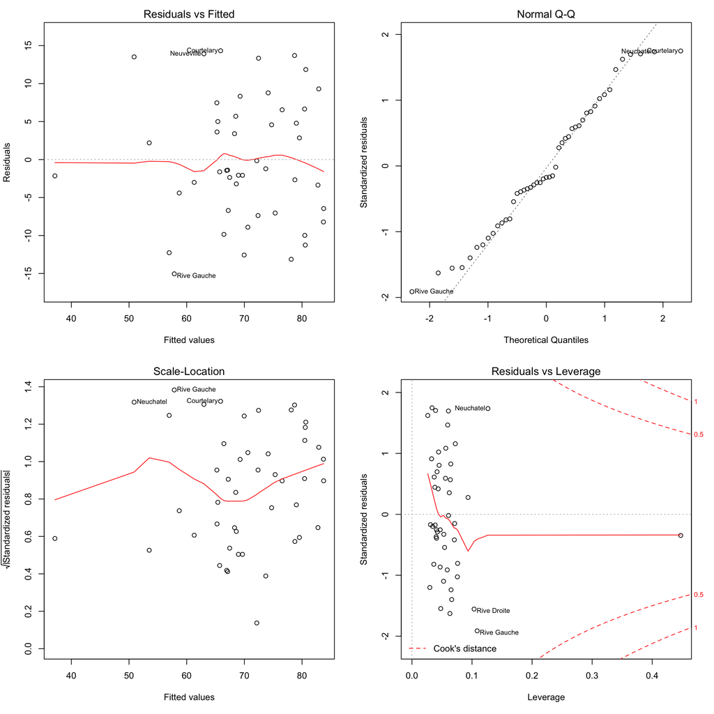

```r
par(mfrow=c(2,2))
plot(model)
```

To note here, especially, is that the average of the residuals across the fitted values is approximately zero and that the points in the Normal Q-Q plot land close to the diagonal. The former indicates that there are no unmodelled non-linearities in the data, whereas the latter indicates that the residuals conform to the normality assumption.

What about the role of the explanatory variables then? To see how exactly do the predictors associate with the response, we can examine the model *coefficients*. Here the model coefficients indicate that where there are more catholics fertility is higher, whereas highher education tends to reduce fertility:

```r
model$coefficients
```

```
(Intercept)    Catholic   Education
 74.2336892   0.1109210  -0.7883293
```

We can also visialize these associations:

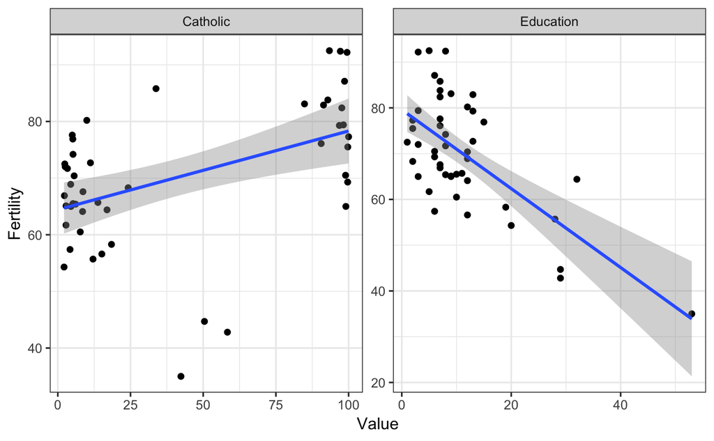

```r
library(tidyr)
library(dplyr)
library(ggplot2)

swiss %>%
  select(Fertility, Catholic, Education) %>%
  gather('Predictor','Value',-Fertility) %>%
  ggplot(aes(Value,Fertility)) +
    geom_point() +
    geom_smooth(method = 'lm') +
    facet_wrap(~Predictor, scales='free') +
    theme_bw()
```

## 1.3 *Refining the model*

From the plot above it looks like the % of catholics is actually more like a binary variable than a continuous value, as only a few provinces have intermediate %-values. What we could do here is to categorize the `Catholic` variable and fit a new model:

```r
df = mutate(swiss,c_Catholic = ifelse(Catholic<50,
                             'Non-catholic','Catholic'))

model2 = lm(Fertility~c_Catholic * Education, data=df)

summary(model2)
```

```
Call:
lm(formula = Fertility ~ c_Catholic * Education, data = df)

Residuals:
    Min      1Q  Median      3Q     Max
-12.476  -6.238  -1.681   6.383  16.519

Coefficients:
                                 Estimate
(Intercept)                       89.2178
c_CatholicNon-catholic           -15.7685
Education                         -1.4001
c_CatholicNon-catholic:Education   0.8046
                                 Std. Error
(Intercept)                          2.9766
c_CatholicNon-catholic               3.7799
Education                            0.2500
c_CatholicNon-catholic:Education     0.2896
                                 t value Pr(>|t|)
(Intercept)                       29.973  < 2e-16
c_CatholicNon-catholic            -4.172 0.000144
Education                         -5.601 1.39e-06
c_CatholicNon-catholic:Education   2.778 0.008067

(Intercept)                      ***
c_CatholicNon-catholic           ***
Education                        ***
c_CatholicNon-catholic:Education **
---
Signif. codes:
0 ‘***’ 0.001 ‘**’ 0.01 ‘*’ 0.05 ‘.’ 0.1 ‘ ’ 1

Residual standard error: 8.13 on 43 degrees of freedom
Multiple R-squared:  0.604, Adjusted R-squared:  0.5764
F-statistic: 21.86 on 3 and 43 DF,  p-value: 9.405e-09
```

Now an interaction between the predictors is included and we have a slight improvent in model fit (as judged by the `R-squared` value).

The interaction becomes evident in the following plot:

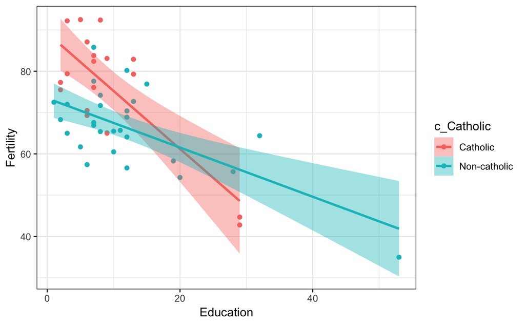

```r
df %>%
  select(Fertility, c_Catholic, Education) %>%
  ggplot(aes(Education,Fertility,
             col = c_Catholic, fill = c_Catholic)) +
    geom_point() +
    geom_smooth(method = 'lm') +
    theme_bw()
```

# 2 GLM models

In **R**, function `glm()` is used to fit generalized linear models. The generalisation means that the user can specify the shape of the error distribution.

## 2.1 *Logistic regression*

Logistic regression is used when the response variable is binary. Such an analysis is made when setting the `family` argument in `glm()` equal to `"binomial"`. Here the regression fit is not linear, but a sigmoidal curve.

For example:

```r
# Get data:
data(iris)

# Make response:
iris$is_setosa = ifelse(iris$Species=='setosa',1,0)

# Fit model:
model = glm(is_setosa~Sepal.Length, family="binomial",data = iris)

# Calculate R-squared:
round(1 - (model$deviance/model$null.deviance),2)
```

```
[1] 0.62
```

To visualize the regression:

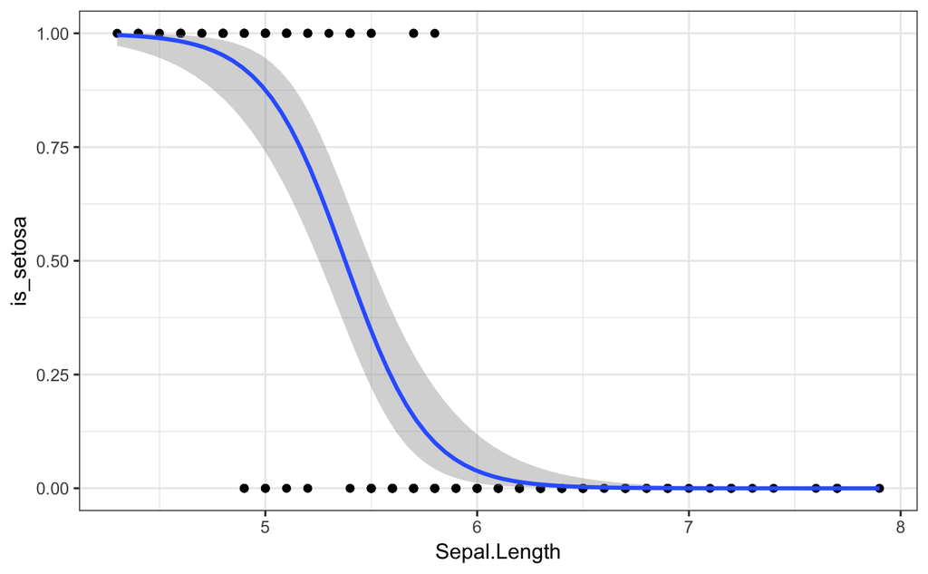

```r
ggplot(iris,aes(Sepal.Length,is_setosa)) +
  geom_point() +
  stat_smooth(method='glm',
              method.args = list(family='binomial')) +
  theme_bw()
```

## 2.2 *Poisson regression*

If the response variable is a positive integer, it technically follows a *Poisson* distribution. Such data naturally arises when counts are recorded or when counts result from cross-tabulation of data.

```r
# Make example data:
counts = c(18,17,15,28,25,16,14,11,9)
outcome = gl(3,1,9)
treatment = gl(3,3)
df = data.frame(treatment, outcome, counts)
df
```

| treatment | outcome | counts |
| --- | --- | --- |
| 1 | 1 | 18 |
| 1 | 2 | 17 |
| 1 | 3 | 15 |
| 2 | 1 | 28 |
| 2 | 2 | 25 |
| 2 | 3 | 16 |
| 3 | 1 | 14 |
| 3 | 2 | 11 |
| 3 | 3 | 9 |

This imaginary experimental data has a treatment with 3 levels and for each treatment there are 3 outcomes. For each combination there is a count of observations.

We can then fit a `glm` model, this time setting the error distribution to `"poisson"`:

```r
# Fit model:
model = glm(counts ~ outcome + treatment, family = 'poisson')

# Get statistics from a Chi-square test:
anova(model, test = 'Chi')
```

```
Analysis of Deviance Table

Model: poisson, link: log

Response: counts

Terms added sequentially (first to last)

          Df Deviance Resid. Df Resid. Dev
NULL                          8    17.1283
outcome    2    4.144         6    12.9843
treatment  2   12.163         4     0.8214
          Pr(>Chi)
NULL
outcome   0.125933
treatment 0.002285 **
---
Signif. codes:
0 ‘***’ 0.001 ‘**’ 0.01 ‘*’ 0.05 ‘.’ 0.1 ‘ ’ 1
```